# Capstone report

Stephanie

## 1 Background of SwiftKey project:

SwiftKey is a smart keyboard that makes it easier for people to type on their mobile devices. A good example is that when you type a sentence or a phrase, the keyboard presents some options for what the next word might be. en _US is used to analysis english version of text data. In this report I use three data files: twitts, blogs and news inside en _US.

## 2 Concept of n-gram:

An n-gram is a contiguous sequence of n items from a given sequence of text or speech. The items can be phonemes, syllables, letters, words or base pairs according to the application. The n-grams typically are collected from a text or speech corpus. An n-gram of size 1 is referred to as a “unigram”; size 2 is a “bigram”; size 3 is a “trigram”. In this project we will use 2-gram(bigram), 3-gram(trigram), and 4-gram(quadgram) in the prediction.

The next step is tokenize sentences. Tokenization is the process of breaking a stream of text up into words, phrases, symbols, or other meaningful elements called tokens. For example, tokenize “how are you” into 2-grams returns two elements : “how are” , “are you”).

## 3 Basic summary of data:

Let’s see how many lines and how many words in each data file: twitts, blogs, news.

```
##     file   lines    words
## 1 twitts 2360148 30433240
## 2   news 1010242 35710862
## 3  blogs  899288 38222278
```

## 4 Visualization of data:

unigram wordcloud for twitts, news and blogs(from left to right):

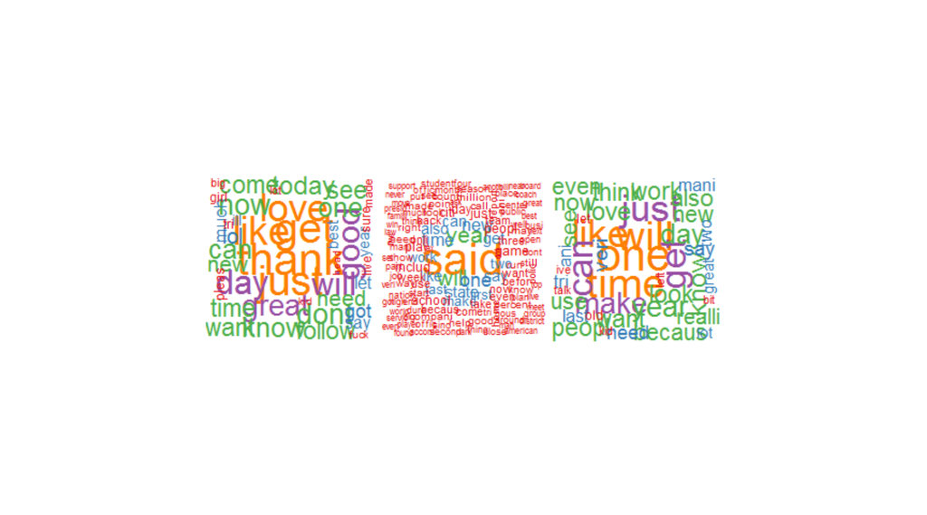

Then combine twitts, news and blogs together to do the below visualizations:

## unigram corpus visualization:

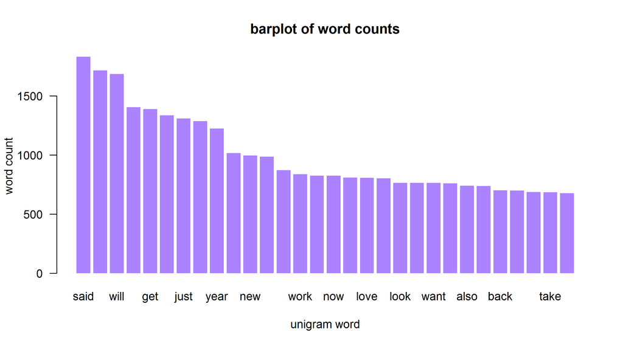

## 2-gram corpus visualization:

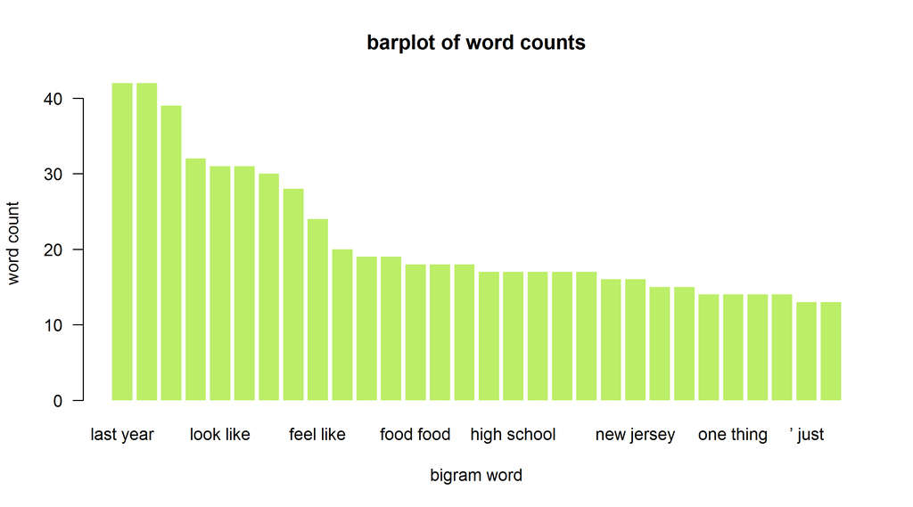

## 3-gram corpus visualization:

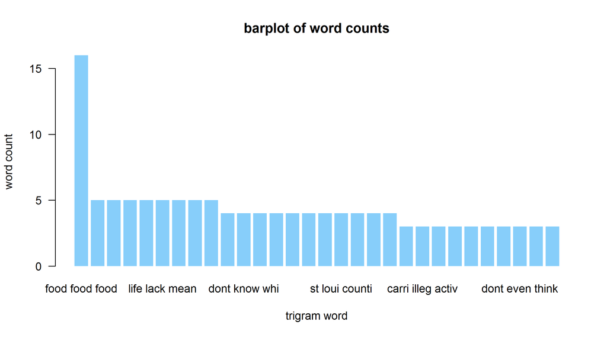

## 5 Future plan(shiny app)

About shiny app

My app is designed to use on mobile phone. It has input part and output part to show the predicted next word. Below there are some points that gives me a clear structure on building this app:

- The interface of my shiny app generally consists of two pages(input & output page, introduction page).
- In the first page, it has two parts: input part(ngram method input part, and sentence text input part), and output part(next single word output part, and the other possible words output part).

Instruction on how to use it:

1. First, select ngram method(2gram, 3gram or 4gram), then type sentence in the text input part.
2. Second, click “update” button and check output(to see possible next word).
3. The input sentence is cleaned (change to lower case, remove whitespace, punctuation,stopwords, etc. ). Use model I create and use algorithm to predict based on input sentence.

About my ngram model:

- 4-gram takes last 3 words in a sentence/phrase(input), then search 4-gram tables and find 4-gram with highest frequency. Last word of 4-gram is what we want. 3-gram takes last 2 words; 2-gram takes last one word.
- back off method: if it returns no observation with 4-gram method, then it backs off to its lower gram method(that is 3-gram method) until it has possible output word.

## 6 Reference:

1. http://en.wikipedia.org/wiki/N-gram
2. https://class.coursera.org/nlp
3. Download data from a corpus called HC Corpora http://www.corpora.heliohost.org
4. See the readme file at http://www.corpora.heliohost.org/aboutcorpus.html for details